# DS 2020 - Summer 2026 - Homework #2

David Lawlor

# Lab: Ames Housing Data Exploration

## Overview

In this lab, you will explore the `ames` dataset from the `classdata` package, which contains residential sales data in Ames, Iowa since 2017. All work should be completed in this `.Rmd` file and submitted through Canvas.

```r
library(classdata)
library(dplyr)
```

```r
library(ggplot2)

ames <- ames %>%
  rename(Sale_Price = `Sale Price`,
         Living_Area = `TotalLivingArea (sf)`)
```

The main variable of interest is `Sale_Price`. You will:

- Investigate this variable and its distribution
- Identify and explore one other variable that may relate to `Sale_Price`
- Use code, visualizations, and written explanation to communicate your findings

Make sure your `.Rmd` file knits cleanly to `.html`. You will submit both the `.Rmd` and the knitted output.

## Step 1: Data Exploration

1. Inspect the first few lines of the data set:
   - What variables are there?
   - Of what type are the variables?
   - What does each variable mean?
   - What do you expect their data ranges to be?

The dataset has 16 variables covering property identifiers, characteristics (Style, YearBuilt, Bedrooms, Living Area), and sale details (Sale Price, Sale Date). Types are mostly character/text, numeric, and a few date/logical columns. I expected typical residential ranges and prices in the tens of thousands to low millions, bedrooms 1–6, year built early 1900s to present.

```r
head(ames)
```

```
## # A tibble: 6 x 16
##   `Parcel ID` Address        Style Occupancy `Sale Date` Sale_Price `Multi Sale`
##   <chr>       <chr>          <fct> <fct>     <date>           <dbl> <chr>
## 1 0903202160  1024 RIDGEWOO~ 1 1/~ Single-F~ 2022-08-12      181900 <NA>
## 2 0907428215  4503 TWAIN CI~ 1 St~ Condomin~ 2022-08-04      127100 <NA>
## 3 0909428070  2030 MCCARTHY~ 1 St~ Single-F~ 2022-08-15           0 <NA>
## 4 0923203160  3404 EMERALD ~ 1 St~ Townhouse 2022-08-09      245000 <NA>
## 5 0520440010  4507 EVEREST ~ <NA>  <NA>      2022-08-03      449664 <NA>
## 6 0907275030  4512 HEMINGWA~ 2 St~ Single-F~ 2022-08-16      368000 <NA>
## # i 9 more variables: YearBuilt <dbl>, Acres <dbl>, Living_Area <dbl>,
## #   Bedrooms <dbl>, `FinishedBsmtArea (sf)` <dbl>, `LotArea(sf)` <dbl>,
## #   AC <chr>, FirePlace <chr>, Neighborhood <fct>
```

```r
glimpse(ames)
```

```
## Rows: 6,935
## Columns: 16
## $ `Parcel ID`             <chr> "0903202160", "0907428215", "0909428070", "092~
## $ Address                 <chr> "1024 RIDGEWOOD AVE, AMES", "4503 TWAIN CIR UN~
## $ Style                   <fct> 1 1/2 Story Frame, 1 Story Frame, 1 Story Fram~
## $ Occupancy               <fct> Single-Family / Owner Occupied, Condominium, S~
## $ `Sale Date`             <date> 2022-08-12, 2022-08-04, 2022-08-15, 2022-08-0~
## $ Sale_Price              <dbl> 181900, 127100, 0, 245000, 449664, 368000, 0, ~
## $ `Multi Sale`            <chr> NA, NA, NA, NA, NA, NA, NA, NA, NA, NA, NA, NA~
## $ YearBuilt               <dbl> 1940, 2006, 1951, 1997, NA, 1996, 1960, 2006, ~
## $ Acres                   <dbl> 0.109, 0.027, 0.321, 0.103, 0.287, 0.494, 0.17~
## $ Living_Area             <dbl> 1030, 771, 1456, 1289, NA, 2223, 1165, 658, 13~
## $ Bedrooms                <dbl> 2, 1, 3, 4, NA, 4, 5, 1, 3, 4, 4, 2, 2, 3, 2, ~
## $ `FinishedBsmtArea (sf)` <dbl> NA, NA, 1261, 890, NA, NA, 906, NA, NA, 500, 5~
## $ `LotArea(sf)`           <dbl> 4740, 1181, 14000, 4500, 12493, 21533, 7500, 1~
## $ AC                      <chr> "Yes", "Yes", "Yes", "Yes", "No", "Yes", "Yes"~
## $ FirePlace               <chr> "Yes", "No", "No", "No", "No", "Yes", "Yes", "~
## $ Neighborhood            <fct> (28) Res: Brookside, (55) Res: Dakota Ridge, (~
```

```r
names(ames)
```

```
##  [1] "Parcel ID"             "Address"               "Style"
##  [4] "Occupancy"             "Sale Date"             "Sale_Price"
##  [7] "Multi Sale"            "YearBuilt"             "Acres"
## [10] "Living_Area"           "Bedrooms"              "FinishedBsmtArea (sf)"
## [13] "LotArea(sf)"           "AC"                    "FirePlace"
## [16] "Neighborhood"
```

2. Begin the exploration with the main variable, `Sale_Price`:
   - What is the range of this variable?
   - Create a histogram to visualize the distribution.
   - What is the general pattern? Are there any unusual or extreme values?

[output not shown]

```r
summary(ames$Sale_Price)
```

```
##     Min.  1st Qu.   Median     Mean  3rd Qu.     Max.
##        0        0   170900  1017479   280000 20500000
```

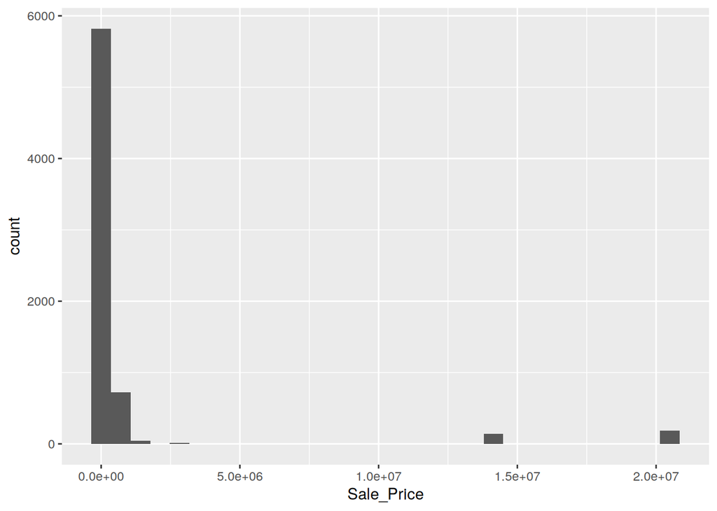

```r
ggplot(ames, aes(x = Sale_Price)) + geom_histogram(bins = 30)
```

3. Choose a second variable that may relate to `Sale_Price`:
   - What is the range of this variable? Plot it and describe the pattern.
   - Explore the relationship between this variable and `Sale_Price`. Use a scatterplot, boxplot, or faceted bar chart—whichever is most appropriate.
   - Describe the pattern. Does this second variable help explain anything you observed in `Sale_Price`?

```r
range(ames$Living_Area)
```

```
## [1] NA NA
```

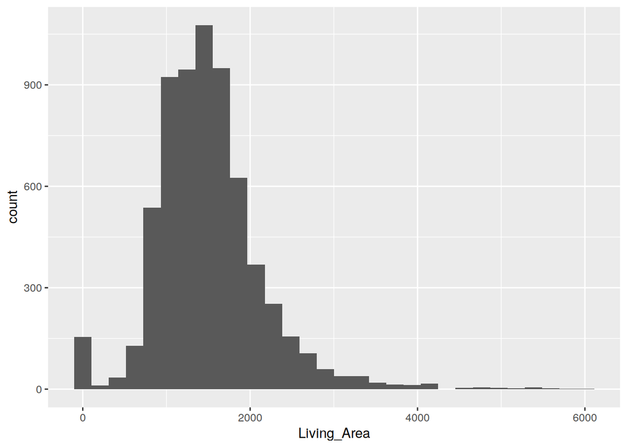

```r
ggplot(ames, aes(x = Living_Area)) +
  geom_histogram(bins = 30)
```

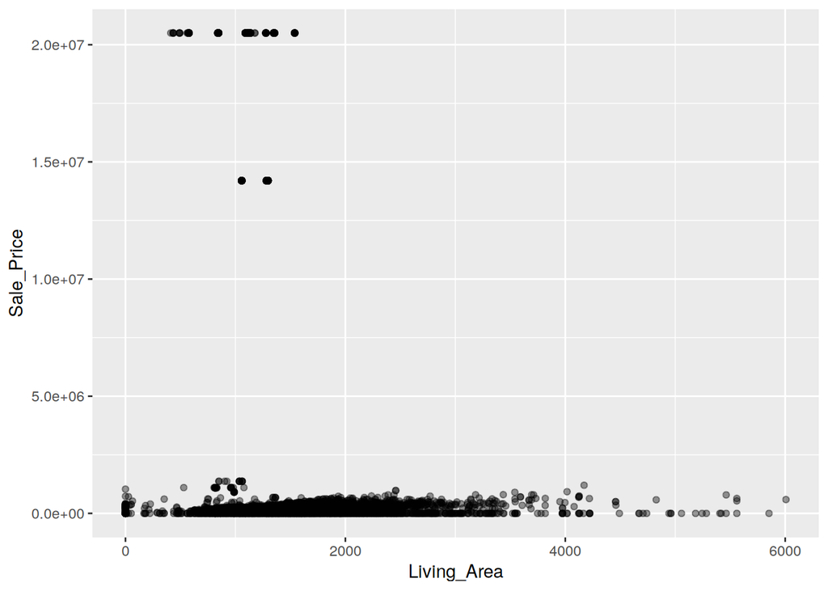

```r
ggplot(ames, aes(x = Living_Area, y = Sale_Price)) +
  geom_point(alpha = 0.4)
```

# Homework Assignment

## Chick Weights

The `ChickWeight` data set is part of the base package `datasets`. See `?ChickWeight` for details on the data. For all of the questions use `dplyr` functions whenever possible.

1. Download the RMarkdown file with these homework instructions to use as a template for your work. Make sure to replace “Your Name” in the YAML with your name. To get full points, show your R code (in a code chunk) and write answers to the questions.
2. What variables are part of the dataset?

```r
data(ChickWeight)
glimpse(ChickWeight)
```

```
## Rows: 578
## Columns: 4
## $ weight <dbl> 42, 51, 59, 64, 76, 93, 106, 125, 149, 171, 199, 205, 40, 49, 5~
## $ Time   <dbl> 0, 2, 4, 6, 8, 10, 12, 14, 16, 18, 20, 21, 0, 2, 4, 6, 8, 10, 1~
## $ Chick  <ord> 1, 1, 1, 1, 1, 1, 1, 1, 1, 1, 1, 1, 2, 2, 2, 2, 2, 2, 2, 2, 2, ~
## $ Diet   <fct> 1, 1, 1, 1, 1, 1, 1, 1, 1, 1, 1, 1, 1, 1, 1, 1, 1, 1, 1, 1, 1, ~
```

ChickWeight has four variables: weight, Time, Chick, and Diet.

3. Get a frequency breakdown of the number of chicks, their average weight and the standard deviation of the weights in each of the diets at the start of the study.
- extra credit: construct a ggplot that shows average weights by diet with an interval (shown as a line) of +- the standard deviation around the averages. (Hint: read this article regarding [ggplot error bars](http://www.sthda.com/english/wiki/ggplot2-error-bars-quick-start-guide-r-software-and-data-visualization))

```r
chick_start <- ChickWeight %>%
  filter(Time == 0) %>%
  group_by(Diet) %>%
  summarise(n_chicks = n(),
            avg_weight = mean(weight),
            sd_weight = sd(weight))

chick_start
```

```
## # A tibble: 4 x 4
##   Diet  n_chicks avg_weight sd_weight
##   <fct>    <int>      <dbl>     <dbl>
## 1 1           20       41.4     0.995
## 2 2           10       40.7     1.49
## 3 3           10       40.8     1.03
## 4 4           10       41       1.05
```

Diets aren’t evenly split. Diet 1 has 20 chicks in it while diets 2, 3, and 4 only have 10 each. The average starting weight is basically the same across all four diets, somewhere between about 40.7 and 41.4 grams, and honestly that makes sense once you think about it. Since Time 0 is the very start of the study, no chick has actually eaten any of the diets yet, so there’s no reason diet would be affecting weight at this point. The standard deviations are all pretty small too, so the chicks started out fairly similar in size regardless of which group they ended up in.

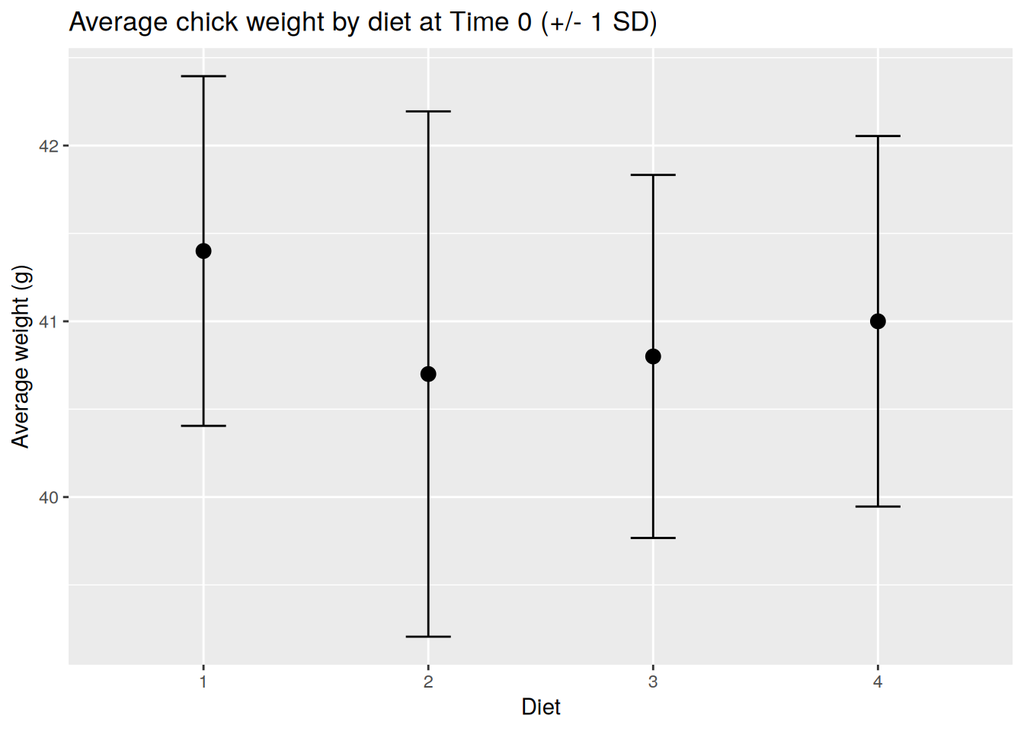

```r
ggplot(chick_start, aes(x = Diet, y = avg_weight)) +
  geom_point(size = 3) +
  geom_errorbar(aes(ymin = avg_weight - sd_weight, ymax = avg_weight + sd_weight),
                width = 0.2) +
  labs(y = "Average weight (g)",
       title = "Average chick weight by diet at Time 0 (+/- 1 SD)")
```

Four dots sitting at almost the same height with small error bars, since there’s no real difference between diets yet at day 0.

4. Each chick should have twelve weight measurements. Use the `dplyr` package to identify how many chicks have a complete set of weight measurements and how many measurements there are on average in the incomplete cases. Extract a subset of the data for all chicks with complete information and name the data set `complete`. (Hint: you might want to use mutate to introduce a helper variable consisting of the number of observations)

```r
chick_counts <- ChickWeight %>%
  mutate(n_obs = n(), .by = Chick) %>%
  distinct(Chick, n_obs)

table(chick_counts$n_obs)
```

```
##
##  2  7  8 10 11 12
##  1  1  1  1  1 45
```

```r
incomplete <- chick_counts %>% filter(n_obs < 12)
nrow(incomplete)
```

```
## [1] 5
```

```r
mean(incomplete$n_obs)
```

```
## [1] 7.6
```

```r
complete <- ChickWeight %>%
  mutate(n_obs = n(), .by = Chick) %>%
  filter(n_obs == 12)
```

Using mutate with .by = Chick to count observations per chick, I found 45 of the 50 chicks have the full 12 measurements. The other 5 are incomplete, with counts of 2, 7, 8, 10, and 11, averaging 7.6 measurements each. That spread suggests those chicks probably dropped out of the study early rather than just missing a measurement or two. The complete dataset ends up with 540 rows.

5. In the complete data set introduce a new variable that measures the current weight difference compared to day 0. Name this variable `weightgain`. (Hint: use mutate and `?mutate` to check the parameter `.by`. This parameter can create a temporary `group_by` so that we can do calculation in each subgroup, i.e. for each combination of chick and diet,

   ```
   weight -
   min(weight)
   ```

   )

```r
complete <- complete %>%
  mutate(weightgain = weight - min(weight), .by = c(Chick, Diet))
```

Using .by = c(Chick, Diet), weightgain comes out to 0 at Time 0 for almost every chick, since their lowest weight is their starting weight. One chick (Chick 3) is an exception with weightgain of 4 at Time 0, since it weighed less at a later point than on day 0.

6. Use `ggplot2` to create side-by-side boxplots of `weightgain` by `Diet` for day 21. Describe the relationship in 2-3 sentences. Change the order of the categories in the Diet variable such that the boxplots are ordered by median `weightgain`.

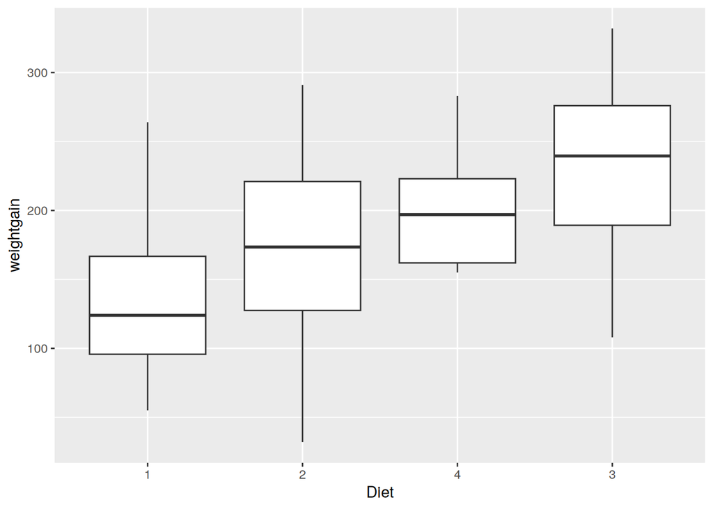

```r
day21 <- complete %>% filter(Time == 21)

day21 <- day21 %>%
  mutate(Diet = forcats::fct_reorder(Diet, weightgain, median))

ggplot(day21, aes(x = Diet, y = weightgain)) +
  geom_boxplot()
```

Note: Your submission is supposed to be fully reproducible, i.e. the TA and I will ‘knit’ your submission in RStudio.

For the submission: submit your solution in an R Markdown file and (just for insurance) submit the corresponding html (or Word) file with it.

(Optional but encouraged):  
If you’d like to practice using GitHub, feel free to push your `.Rmd` and knitted `.html` file to a **public GitHub repository** under your own account. If you do, paste the link to your GitHub repo below:

> GitHub repo link (optional): `__________`